# Machine Learning Project

Kumar Velugula

June 21, 2015

# Executive Summary

The goal of the project is to predict the manner (how well they have done it) in which a group of 6 enthusiasts did the exercises based on the training/test data collected from accelormeters fitted to different parts of their bodies. Particularly “classe” variable in the training set will be used to predict with.

This document is a report describing how model is built, how cross validation is used, what the expected out of sample error is, and why certain choices are made in due course.

Based on the detailed analysis presented below, it is possible to accurately predict how well the enthusiast is performing exercise using the Random Forest algorithm.

The data for this project came from this source: http://groupware.les.inf.puc-rio.br/har

Note: To load data and initialize the models/plots it may take upto 1-2 minutes

```r
#load dependencies
#Please make sure listed below packages are installed before proceeding
library(caret)
```

```r
library(rpart)
library(rpart.plot)
library(RColorBrewer)
library(rattle)
library(randomForest)
```

## Getting and Cleaning data

```r
downloadSourceFiles <- function(){
        ##check if both the required files exists in the current working directory,
        ##if any one of them is missing, re-download the zip file and unzip to download both the files
        if(file.exists("pml-training.csv") == FALSE
           | file.exists("pml-testing.csv") == FALSE ){
                #training data location
                trainingUrl <- "https://d396qusza40orc.cloudfront.net/predmachlearn/pml-training.csv"
                #The test data are available here:
                testUrl <- "https://d396qusza40orc.cloudfront.net/predmachlearn/pml-testing.csv"

                ## download file with name "pml-training.csv"
                download.file(trainingUrl,dest="pml-training.csv", method="curl", mode="wb")
                ## download file with name "pml-testing.csv"
                download.file(testUrl,dest="pml-testing.csv", method="curl", mode="wb")

                print ('Required files 1. pml-training.csv and 2. pml-testing.csv are downloaded.')

        }
        else {
                print ('Required files 1. pml-training.csv and 2. pml-testing.csv already exists and not re-downloading')
        }
}
downloadSourceFiles();
```

```
## [1] "Required files 1. pml-training.csv and 2. pml-testing.csv already exists and not re-downloading"
```

```r
#all NA like values including blanks are explicitly set to be interpreted as NA values
pmlTrainingData <- read.csv("pml-training.csv", na.strings=c("NA",""," "))
pmlTestingData <- read.csv("pml-testing.csv", na.strings=c("NA",""," "))

#From training data remove columns with all NA values explicitly so that it won't interfere with modeling algorithms
naPredicate <- apply(pmlTrainingData, 2, function(itemVal) sum(is.na(itemVal)));
pmlTrainigDataCleaned <- pmlTrainingData[, which(naPredicate == 0)];

#From trainingDataCleaned, remove identifier columns, timestamp etc., as they are not relevant to the modeling
pmlTrainigDataCleaned <- pmlTrainigDataCleaned[8:length(pmlTrainigDataCleaned)]


naPredicateTest <- apply(pmlTestingData, 2, function(itemVal) sum(is.na(itemVal)));
pmlTestDataCleaned <- pmlTestingData[, which(naPredicateTest == 0)];

#From pmlTestDataCleaned, remove identifier columns, timestamp etc., as they are not relevant to the modeling
pmlTestDataCleaned <- pmlTestDataCleaned[8:length(pmlTestDataCleaned)]

#Towards reproducibilty setting the seed
set.seed(654321)
```

## Exploratory Data Analysis

```r
#Quick look at the cleaned data frame
str(pmlTrainigDataCleaned)
```

```
## 'data.frame':    19622 obs. of  53 variables:
##  $ roll_belt           : num  1.41 1.41 1.42 1.48 1.48 1.45 1.42 1.42 1.43 1.45 ...
##  $ pitch_belt          : num  8.07 8.07 8.07 8.05 8.07 8.06 8.09 8.13 8.16 8.17 ...
##  $ yaw_belt            : num  -94.4 -94.4 -94.4 -94.4 -94.4 -94.4 -94.4 -94.4 -94.4 -94.4 ...
##  $ total_accel_belt    : int  3 3 3 3 3 3 3 3 3 3 ...
##  $ gyros_belt_x        : num  0 0.02 0 0.02 0.02 0.02 0.02 0.02 0.02 0.03 ...
##  $ gyros_belt_y        : num  0 0 0 0 0.02 0 0 0 0 0 ...
##  $ gyros_belt_z        : num  -0.02 -0.02 -0.02 -0.03 -0.02 -0.02 -0.02 -0.02 -0.02 0 ...
##  $ accel_belt_x        : int  -21 -22 -20 -22 -21 -21 -22 -22 -20 -21 ...
##  $ accel_belt_y        : int  4 4 5 3 2 4 3 4 2 4 ...
##  $ accel_belt_z        : int  22 22 23 21 24 21 21 21 24 22 ...
##  $ magnet_belt_x       : int  -3 -7 -2 -6 -6 0 -4 -2 1 -3 ...
##  $ magnet_belt_y       : int  599 608 600 604 600 603 599 603 602 609 ...
##  $ magnet_belt_z       : int  -313 -311 -305 -310 -302 -312 -311 -313 -312 -308 ...
##  $ roll_arm            : num  -128 -128 -128 -128 -128 -128 -128 -128 -128 -128 ...
```

[output cut: 39 more lines]

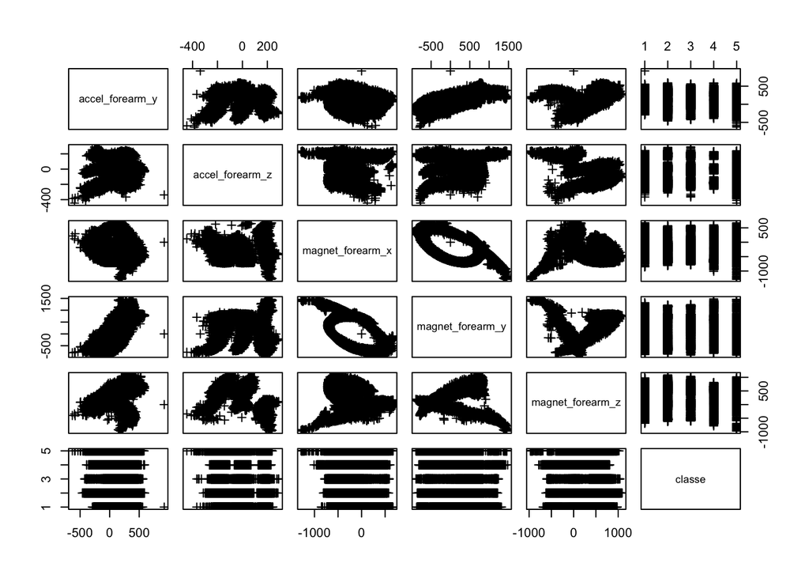

```r
#Quick preview of the observed data in first 5 columns
#pairs(pmlTrainigDataCleaned[,c(1:5)], pch=3)
#Quick preview of the observed data in last 5 columns
pairs(pmlTrainigDataCleaned[,c(48:53)], pch=3)
```

## Create train/test partitions

Splitting data set into 70/30 ratio for training and cross validation respectively

```r
#Split the pmlTrainigDataCleaned data into training and cross validation data sets
inTraining <- createDataPartition(y=pmlTrainigDataCleaned$classe, p=0.7, list=FALSE)
training <- pmlTrainigDataCleaned[inTraining,]
crossVal <- pmlTrainigDataCleaned[-inTraining,]
```

## Using Decision Tree algorithm for prediction

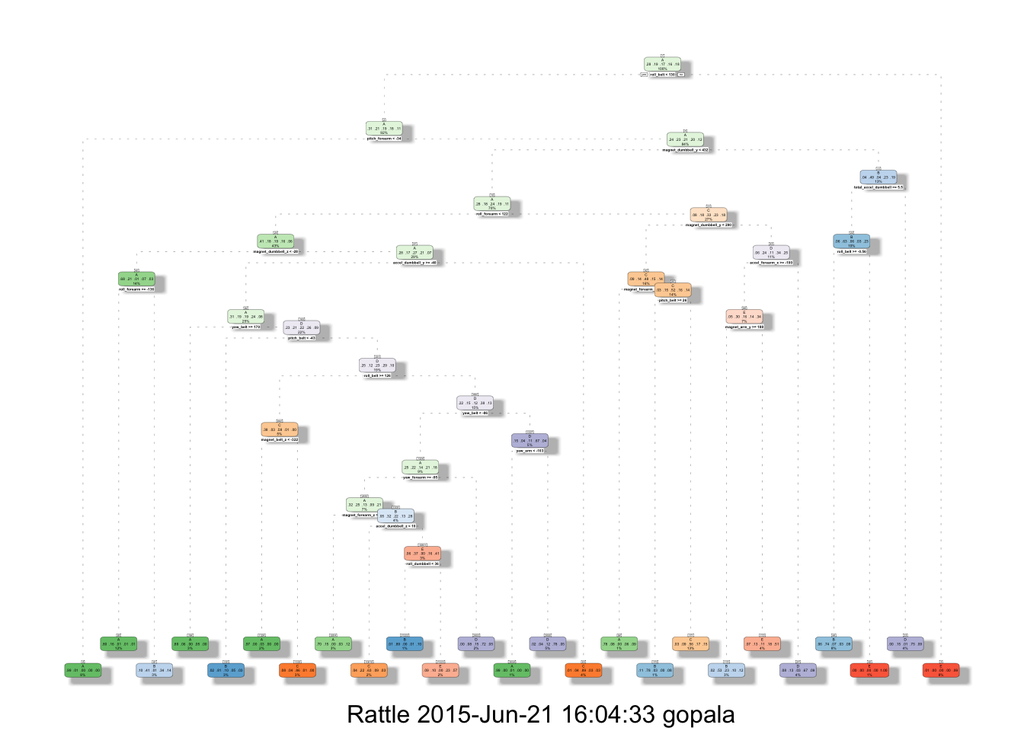

```r
#generate the model using Decision Tree algorithm
dtModel <- rpart(classe ~., data=training, method="class")
#create model plot
fancyRpartPlot(dtModel)
```

```r
#predict using the above model against the crossValidation set
dtPrediction <- predict(dtModel, crossVal,type="class")
#generate confusion matrix for reviewing the accuracy levels
confusionMatrix(dtPrediction, crossVal$classe)
```

```
## Confusion Matrix and Statistics
##
##           Reference
## Prediction    A    B    C    D    E
##          A 1512  153   13   32   48
##          B   66  736   91   76   90
##          C   49  109  828  169  135
##          D   13   81   64  609   59
##          E   34   60   30   78  750
##
## Overall Statistics
##
##                Accuracy : 0.7536
##                  95% CI : (0.7424, 0.7646)
##     No Information Rate : 0.2845
##     P-Value [Acc > NIR] : < 2.2e-16
##
##                   Kappa : 0.6878
##  Mcnemar's Test P-Value : < 2.2e-16
##
## Statistics by Class:
##
##                      Class: A Class: B Class: C Class: D Class: E
## Sensitivity            0.9032   0.6462   0.8070   0.6317   0.6932
## Specificity            0.9416   0.9319   0.9049   0.9559   0.9579
## Pos Pred Value         0.8601   0.6950   0.6419   0.7373   0.7878
## Neg Pred Value         0.9607   0.9165   0.9569   0.9298   0.9327
## Prevalence             0.2845   0.1935   0.1743   0.1638   0.1839
## Detection Rate         0.2569   0.1251   0.1407   0.1035   0.1274
## Detection Prevalence   0.2987   0.1799   0.2192   0.1404   0.1618
## Balanced Accuracy      0.9224   0.7891   0.8560   0.7938   0.8256
```

# Using Random Forest algorithm for prediction

```r
#generate the model using Random Forest algorithm
rfModel <- randomForest(classe ~ ., data=training)
#predict using the above model against the crossValidation set
rfPrediction <- predict(rfModel, crossVal, type="class")
#generate confusion matrix for reviewing the accuracy levels
confusionMatrix(rfPrediction, crossVal$classe)
```

```
## Confusion Matrix and Statistics
##
##           Reference
## Prediction    A    B    C    D    E
##          A 1674    0    0    0    0
##          B    0 1139    2    0    0
##          C    0    0 1024   11    5
##          D    0    0    0  952    4
##          E    0    0    0    1 1073
##
## Overall Statistics
##
##                Accuracy : 0.9961
##                  95% CI : (0.9941, 0.9975)
##     No Information Rate : 0.2845
##     P-Value [Acc > NIR] : < 2.2e-16
##
##                   Kappa : 0.9951
##  Mcnemar's Test P-Value : NA
##
## Statistics by Class:
##
##                      Class: A Class: B Class: C Class: D Class: E
## Sensitivity            1.0000   1.0000   0.9981   0.9876   0.9917
## Specificity            1.0000   0.9996   0.9967   0.9992   0.9998
## Pos Pred Value         1.0000   0.9982   0.9846   0.9958   0.9991
## Neg Pred Value         1.0000   1.0000   0.9996   0.9976   0.9981
## Prevalence             0.2845   0.1935   0.1743   0.1638   0.1839
## Detection Rate         0.2845   0.1935   0.1740   0.1618   0.1823
## Detection Prevalence   0.2845   0.1939   0.1767   0.1624   0.1825
## Balanced Accuracy      1.0000   0.9998   0.9974   0.9934   0.9957
```

# Use Random Forest model to predict the cleaned test data from the source

```r
testPrediction <- predict(rfModel, pmlTestDataCleaned)
testPrediction
```

```
##  1  2  3  4  5  6  7  8  9 10 11 12 13 14 15 16 17 18 19 20
##  B  A  B  A  A  E  D  B  A  A  B  C  B  A  E  E  A  B  B  B
## Levels: A B C D E
```

## Generate files for each of the predictions

```r
pml_write_files = function(x){
  n = length(x)
  for(i in 1:n){
    filename = paste0("problem_id_",i,".txt")
    write.table(x[i],file=filename,quote=FALSE,row.names=FALSE,col.names=FALSE)
  }
}
pml_write_files(testPrediction);
```